# A4: Incarceration

```r
library(dplyr)
```

```r
library(ggplot2)
library(leaflet)
library(readr)
library(tidyr)
library(maps)
library(mapdata)
```

### Introduction

The data tool (trends.vera.org) is used for collecting the population of prison and jail at county levels to better understand the current situation in the U.S. The problem domain is an analysis of incarceration trends in the U.S. I have chosen the dataset [Dataset about prison population per county/state](https://github.com/melaniewalsh/Neat-Datasets/blob/main/us-prison-pop.csv?raw=true). This dataset provides comprehensive data on the prison population, including variables such as total prison population, prison population by race (Black, White, Latinx, etc.), and prison population by gender. These variables are crucial for understanding the disparities and trends in incarceration across different demographic groups. Analyzing this data will allow us to explore how incarceration rates vary by race and gender, and how these trends have evolved over time, providing insights into systemic issues and areas that require policy attention. The inclusion of detailed demographic data makes this dataset a valuable resource for identifying patterns of inequality and informing potential reforms in the criminal justice system.

### Summary Information

```r
# Load datasets
prison_pop <- read_csv("https://raw.githubusercontent.com/melaniewalsh/Neat-Datasets/main/us-prison-pop.csv")
```

```
## ──────────────────────────────────────────────────────── Delimiter: "," chr
## (3): state, county_name, urbanicity dbl (33): ...1, fips, year, total_pop,
## total_pop_15to64, total_prison_pop, f...
```

```r
colnames(prison_pop)
```

```
##  [1] "...1"                         "fips"
##  [3] "year"                         "state"
##  [5] "county_name"                  "urbanicity"
##  [7] "total_pop"                    "total_pop_15to64"
##  [9] "total_prison_pop"             "female_prison_pop"
## [11] "male_prison_pop"              "aapi_prison_pop"
## [13] "black_prison_pop"             "latinx_prison_pop"
## [15] "native_prison_pop"            "other_race_prison_pop"
## [17] "white_prison_pop"             "aapi_female_prison_pop"
## [19] "aapi_male_prison_pop"         "black_female_prison_pop"
## [21] "black_male_prison_pop"        "latinx_female_prison_pop"
## [23] "latinx_male_prison_pop"       "native_female_prison_pop"
## [25] "native_male_prison_pop"       "other_race_female_prison_pop"
## [27] "other_race_male_prison_pop"   "white_female_prison_pop"
## [29] "white_male_prison_pop"        "female_pop_15to64"
## [31] "male_pop_15to64"              "aapi_pop_15to64"
## [33] "black_pop_15to64"             "latinx_pop_15to64"
## [35] "native_pop_15to64"            "white_pop_15to64"
```

```r
# 1. Average total prison population across all counties
average_total_prison_pop <- prison_pop %>%
  summarise(avg_total_prison_pop = mean(total_prison_pop, na.rm = TRUE))

# 2. Highest Black prison population
highest_black_prison_pop <- prison_pop %>%
  filter(black_prison_pop == max(black_prison_pop, na.rm = TRUE)) %>%
  select(black_prison_pop)

# 3.Lowest White prison population
lowest_white_prison_pop <- prison_pop %>%
  filter(white_prison_pop == min(white_prison_pop, na.rm = TRUE)) %>%
  select(white_prison_pop)

# 4. Average of change in the total prison population over the past 10 years
change_over_time <- prison_pop %>%
  group_by(year) %>%
  summarise(avg_prison_pop = mean(total_prison_pop, na.rm = TRUE)) %>%
  mutate(change = avg_prison_pop - lag(avg_prison_pop))

recent_change <- change_over_time %>%
  filter(year %in% (max(year) - 9):max(year))

# Calculate the average change over the past 10 years
average_recent_change <- recent_change %>%
  summarise(avg_change = mean(change, na.rm = TRUE))



# 5. Average female prison population
average_female_prison_pop <- prison_pop %>%
  summarise(avg_female_prison_pop = mean(female_prison_pop, na.rm = TRUE))

# Print the summary values
average_total_prison_pop
```

```
## # A tibble: 1 × 1
##   avg_total_prison_pop
##                  <dbl>
## 1                 361.
```

```r
highest_black_prison_pop
```

```
## # A tibble: 1 × 1
##   black_prison_pop
##              <dbl>
## 1            24818
```

```r
lowest_white_prison_pop
```

```
## # A tibble: 1,713 × 1
##    white_prison_pop
##               <dbl>
##  1                0
##  2                0
##  3                0
##  4                0
##  5                0
##  6                0
##  7                0
##  8                0
##  9                0
## 10                0
## # ℹ 1,703 more rows
```

```r
average_recent_change
```

```
## # A tibble: 1 × 1
##   avg_change
##        <dbl>
## 1      -2.41
```

```r
average_female_prison_pop
```

```
## # A tibble: 1 × 1
##   avg_female_prison_pop
##                   <dbl>
## 1                  31.9
```

### The Dataset

How was the data collected or generated?

The data was consolidated through the cooperation of multiple organizations, and they supplemented it with additional information when there were gaps.

Why was the data collected?

The data was collected for understand and know the incarceration trends at county-levels in the U.S. comprehensively. Thus, we can a broad range of understanding in jail and prison population but lack the specific and exact data.

How many observations (rows) are in your data?

```r
p_row <- nrow(prison_pop)
p_row
```

```
## [1] 153811
```

There are 153811 observations in my data.

How many features (columns) are in the data?

```r
p_col <- ncol(prison_pop)
p_col
```

```
## [1] 36
```

What, if any, ethical questions or questions of power do you need to consider when working with this data?

Working with this prison population dataset requires careful consideration of ethical issues and power dynamics. There is a risk of reinforcing negative stereotypes about racial groups due to the disparities highlighted in the data. Systemic biases in data collection, like over-policing and discriminatory sentencing, can skew results. Ensuring data privacy is crucial, and the impact of incomplete or missing data must be acknowledged. Ethical use of the data involves advocating for fair policies and accurate, transparent communication to avoid misinterpretation and promote informed discussions on criminal justice reform.

What are possible limitations or problems with this data? (at least 200 words)

The dataset about prison populations per county/state from the Vera Institute of Justice, while comprehensive, has several limitations and potential problems. One major limitation is the presence of missing or incomplete data. Not all correctional facilities report data consistently, leading to gaps that can affect the reliability and accuracy of the analysis. This inconsistency can also result in significant variations in how different states and counties report their incarceration statistics, introducing potential biases and inaccuracies. Additionally, the dataset is historical and may not fully capture recent changes in incarceration policies or practices. As criminal justice reform efforts gain traction, changes in policies, such as the reduction of mandatory minimum sentences or the decriminalization of certain offenses, may not be reflected in the data. This lag can mislead analyses that aim to assess the current state of incarceration. Another issue is the lack of qualitative data that can provide deeper insights into the reasons behind the trends. Quantitative data alone cannot fully explain the socio-economic and political factors contributing to incarceration rates. Factors such as changes in law enforcement practices, economic conditions, and social movements play a crucial role but are not captured in the dataset. Systemic biases within the criminal justice system, such as over-policing in minority communities and discriminatory sentencing practices, can also influence the data. These biases can result in an over-representation of certain racial groups, particularly Black and Latinx populations, which can skew the analysis and potentially reinforce negative stereotypes. Furthermore, the dataset does not account for the lived experiences of incarcerated individuals or the broader impact of incarceration on communities. This lack of context can lead to an incomplete understanding of the issue and hinder the development of holistic and effective policy solutions. Finally, the interpretation of the data requires careful consideration. Statistical analyses can highlight disparities, but they do not always explain the underlying causes. Simplistic conclusions drawn from complex data can misinform policy decisions. It is essential to approach the data with a critical and nuanced perspective, acknowledging its limitations and considering the broader socio-economic and political contexts that contribute to incarceration trends. In summary, while the dataset is a valuable resource for understanding incarceration trends in the U.S., its limitations and potential biases must be carefully managed to ensure accurate and ethical use.

### Trends Over Time Chart

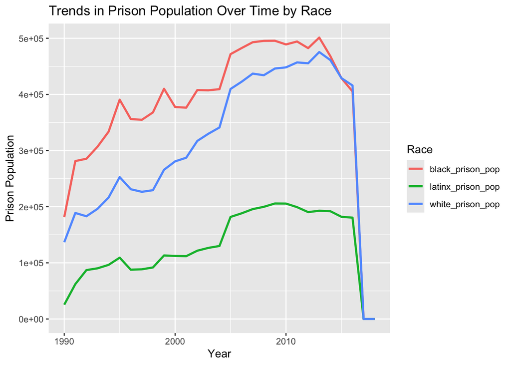

```r
# Prepare the data
trend_data <- prison_pop %>%
  filter(year >= 1990) %>%
  group_by(year) %>%
  summarise(
    black_prison_pop = sum(black_prison_pop, na.rm = TRUE),
    white_prison_pop = sum(white_prison_pop, na.rm = TRUE),
    latinx_prison_pop = sum(latinx_prison_pop, na.rm = TRUE)
  ) %>%
  pivot_longer(cols = c(black_prison_pop, white_prison_pop, latinx_prison_pop), names_to = "race", values_to = "prison_pop")

# Create the line chart
ggplot(trend_data, aes(x = year, y = prison_pop, color = race)) +
  geom_line(size = 1) +
  labs(
    title = "Trends in Prison Population Over Time by Race",
    x = "Year",
    y = "Prison Population",
    color = "Race"
  )
```

### Variable Comparison Chart

The chart titled “Relationship Between Prison Population and Black Prison Population” is a scatter plot illustrating the correlation between the total prison population and the Black prison population across various counties. It shows a positive correlation, indicated by the upward-sloping blue regression line, suggesting that counties with higher total prison populations tend to have higher Black prison populations. The clustering of points around the line reflects a strong relationship, while outliers indicate counties with disproportionate Black prison populations. This visualization was included to highlight potential racial disparities in incarceration and to underscore areas where the Black prison population deviates from the overall trend, warranting further investigation and potential policy interventions.

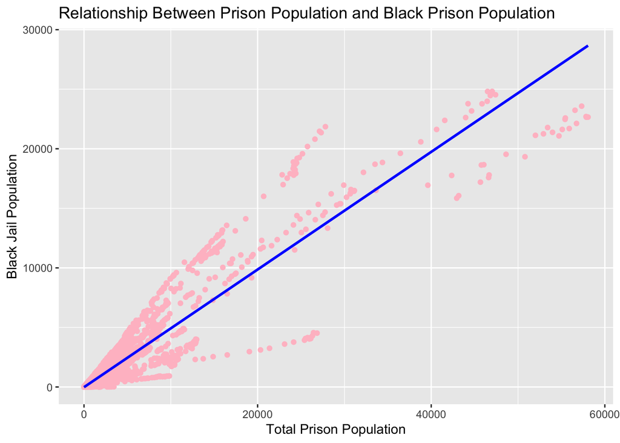

```r
prison_pop <- read_csv("https://raw.githubusercontent.com/melaniewalsh/Neat-Datasets/main/us-prison-pop.csv")
comparison_data <- prison_pop %>%
  filter(!is.na(total_prison_pop) & !is.na(black_prison_pop))

ggplot(data = comparison_data, aes(x = total_prison_pop, y = black_prison_pop)) +
  geom_point(color = "pink") +
  geom_smooth(method=lm, color= "blue",  se=FALSE) +
  labs(title = paste("Relationship Between Prison Population and Black",
                     "Prison Population"),
       x = "Total Prison Population",
       y = "Black Jail Population")
```

### Map

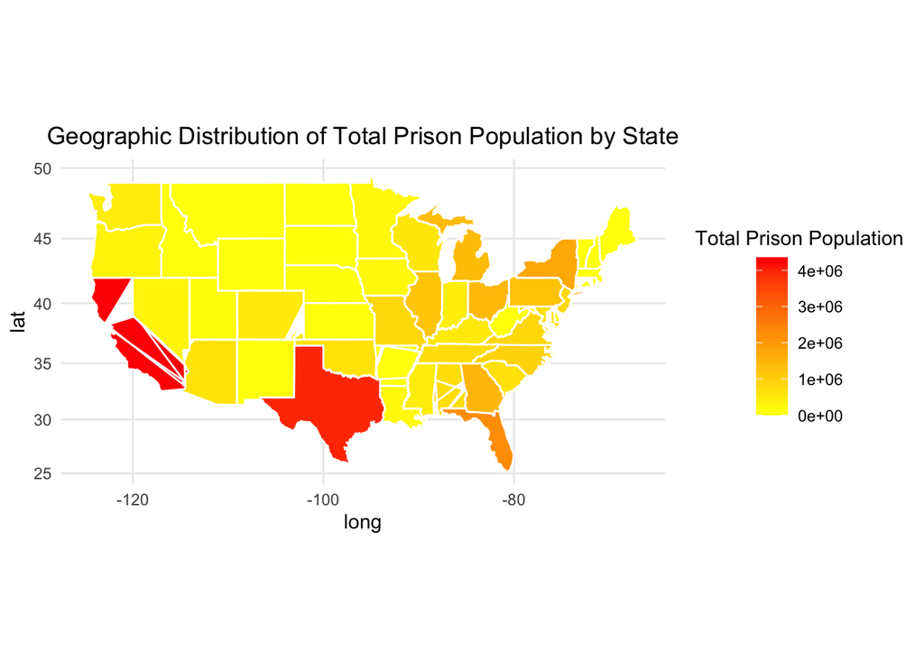

```r
state_abbrev_to_name <- data.frame(
  state = state.abb,
  full_name = tolower(state.name)
)

state_data <- prison_pop %>%
  group_by(state) %>%
  summarise(total_prison_pop = sum(total_prison_pop, na.rm = TRUE)) %>%
  left_join(state_abbrev_to_name, by = "state")

state_data <- state_data %>%
  rename(region = full_name)

us_states <- map_data("state")

map_data <- merge(us_states, state_data, by = "region", all.x = TRUE)

ggplot(map_data, aes(long, lat, group = group, fill = total_prison_pop)) +
  geom_polygon(color = "white") +
  scale_fill_gradient(low = "yellow", high = "red", na.value = "grey50") +
  labs(
    title = "Geographic Distribution of Total Prison Population by State",
    fill = "Total Prison Population"
  ) +
  theme_minimal() +
  theme(
    plot.title = element_text(hjust = 0.5),
    legend.title = element_text(hjust = 0.5)
  ) +
  coord_map()
```